# ggplot visualizations

Tidyverse course: Data Vizualization with ggplot2 (Part 1).

The benefit of importing data with tidyverse is that you can manipulate your data in your script or Rmd file without changing the underlying raw data.

# setup

```r
library(dplyr)
library(ggplot2)
library(readr)
```

# import data

```r
# tsv with readr
gapminder <- read_tsv("gapminder.tsv", col_names = TRUE)
```

# subset data

### `filter()` function

```r
# working with 2007 data only
gapminder_2007 <- gapminder %>%
    filter(year == 2007)
```

You may also want to summarize data. The `summarize()` function is different from filtering.

### `summarize()` function

To summarize many rows into a single data point you can use summarize with the following functions:

- `sum()`
- `mean()`
- `median()`
- `min()`
- `max()`

For example:

```r
# average life expectancy in the year 2007 (all countries)
gapminder %>%
    filter(year == 2007) %>%
    summarize(meanLifeExp = mean(lifeExp))
```

| meanLifeExp |
| --- |
| 67.00742 |

You can also summarize multiple variables at once.

```r
# 1957 median life expectancy and max GDP per capita
gapminder %>%
    filter(year == 1957) %>%
    summarize(medianLifeExp = median(lifeExp),
              maxGdpPercap = max(gdpPercap))
```

| medianLifeExp | maxGdpPercap |
| --- | --- |
| 48.3605 | 113523.1 |

### `group_by()` function

The `group_by()` function can be used with `summarize()` to let you summarize within groups instead of summarizing the entire data set.

```r
# grouping by year
# then summarize mean life expectancy & population
by_year <- gapminder %>%
    group_by(year) %>%
    summarize(meanLifeExp = mean(lifeExp),
              totalPop = sum(pop))

by_year
```

| year | meanLifeExp | totalPop |
| --- | --- | --- |
| 1952 | 49.05762 | 2406957150 |
| 1957 | 51.50740 | 2664404580 |
| 1962 | 53.60925 | 2899782974 |
| 1967 | 55.67829 | 3217478384 |
| 1972 | 57.64739 | 3576977158 |
| 1977 | 59.57016 | 3930045807 |
| 1982 | 61.53320 | 4289436840 |
| 1987 | 63.21261 | 4691477418 |
| 1992 | 64.16034 | 5110710260 |
| 1997 | 65.01468 | 5515204472 |

[output cut: 2 more lines]

```r
# 2007 data, group by continent
by_continent <- gapminder %>%
    filter(year == 2007) %>%
    group_by(continent) %>%
    summarize(meanLifeExp = mean(lifeExp),
              totalPop = sum(pop))

by_continent
```

| continent | meanLifeExp | totalPop |
| --- | --- | --- |
| Africa | 54.80604 | 929539692 |
| Americas | 73.60812 | 898871184 |
| Asia | 70.72848 | 3811953827 |
| Europe | 77.64860 | 586098529 |
| Oceania | 80.71950 | 24549947 |

# scatterplot

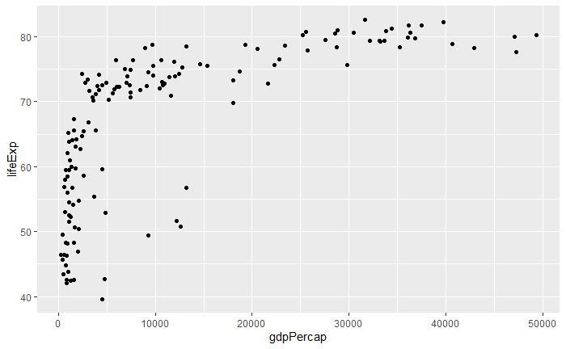

```r
# filtered data 2007
ggplot(gapminder_2007, aes(x = gdpPercap, y = lifeExp)) +
    geom_point()
```

### log scale axis

Log scale: each tick mark is multiplied by a factor.  
Log10 think `10...100...1,000...10,000`  
Log2 think `2...4...8...16`

Another way to think about it:  
`10^1`…`10^2`…`10^3`…`10^4`  
`2^1`…`2^2`…`2^3`…`2^4`

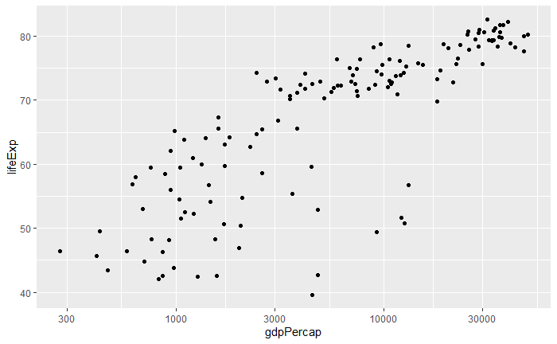

```r
# distribution above on x-axis is too large, add log scale
ggplot(gapminder_2007, aes(x = gdpPercap, y = lifeExp)) +
    geom_point() +
    scale_x_log10()
```

# aesthetics

### color

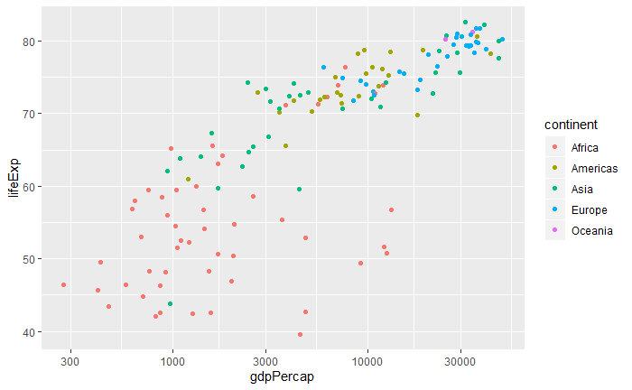

```r
# mapping continent variable to color aesthetic
ggplot(gapminder_2007, aes(x = gdpPercap, y = lifeExp,
                           color = continent)) +
    geom_point() +
    scale_x_log10()
```

### size

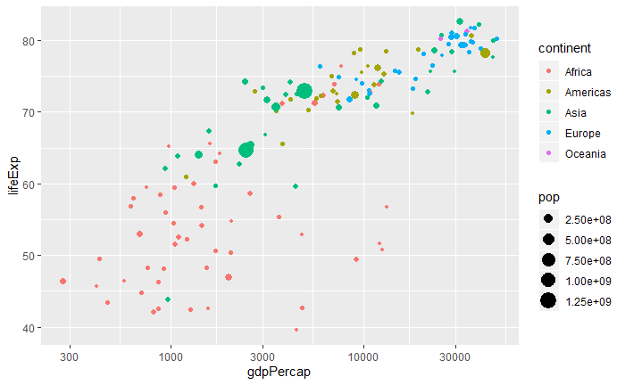

```r
# adding size aesthetic to plot above
ggplot(gapminder_2007, aes(x = gdpPercap, y = lifeExp,
                           color = continent,
                           size = pop)) +
    geom_point() +
    scale_x_log10()
```

# faceting - multiple plots

`~` means “by”, so facet by …

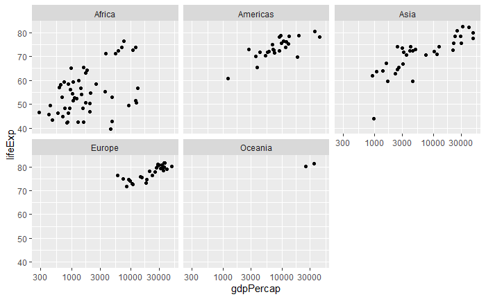

```r
# facet by continent
# removed color aes, explanation below
ggplot(gapminder_2007, aes(x = gdpPercap, y = lifeExp)) +
    geom_point() +
    scale_x_log10() +
    facet_wrap(~ continent)
```

We removed the color aesthetic in the code above because it doesn’t add any new information. Here’s the same code, but keeping the color aesthetic. You can see that it just creates a useless legend.

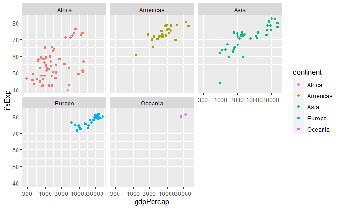

```r
# facet by continent, but keeping color aesthetic mapped to continent
ggplot(gapminder_2007, aes(x = gdpPercap, y = lifeExp,
                           color = continent)) +
    geom_point() +
    scale_x_log10() +
    facet_wrap(~ continent)
```

Note the change in our data. Because we are faceting by year, we need to use the full dataset and not just a single year’s data.

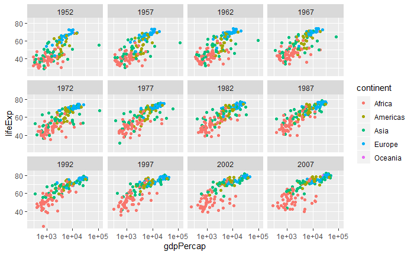

```r
# facet by year
# using gapminder data, not gapminder_2007, added color aesthetic back
ggplot(gapminder, aes(x = gdpPercap, y = lifeExp,
                      color = continent)) +
    geom_point() +
    scale_x_log10() +
    facet_wrap(~ year)
```

# time series & line plots

Visualizing change over time.

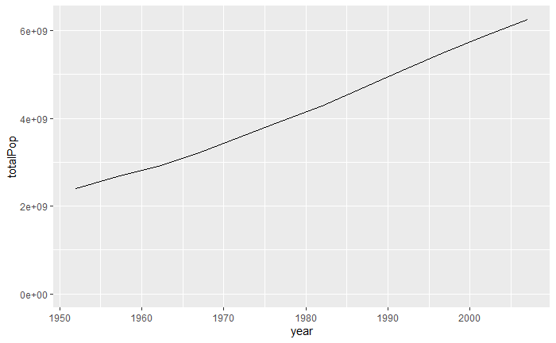

```r
# total population over time
ggplot(by_year, aes(x = year, y = totalPop)) +
    geom_line() +
    expand_limits(y = 0)
```

```r
# new data subset: 5vars = 2groups & 3summarized
by_year_continent <- gapminder %>%
    group_by(year, continent) %>%
    summarize(totalPop = sum(pop),
              meanLifeExp = mean(lifeExp),
              medianGdpPerCap = median(gdpPercap))

head(by_year_continent, 15)
```

| year | continent | totalPop | meanLifeExp | medianGdpPerCap |
| --- | --- | --- | --- | --- |
| 1952 | Africa | 237640501 | 39.13550 | 987.0256 |
| 1952 | Americas | 345152446 | 53.27984 | 3048.3029 |
| 1952 | Asia | 1395357351 | 46.31439 | 1206.9479 |
| 1952 | Europe | 418120846 | 64.40850 | 5142.4697 |
| 1952 | Oceania | 10686006 | 69.25500 | 10298.0857 |
| 1957 | Africa | 264837738 | 41.26635 | 1024.0230 |
| 1957 | Americas | 386953916 | 55.96028 | 3780.5467 |
| 1957 | Asia | 1562780599 | 49.31854 | 1547.9448 |
| 1957 | Europe | 437890351 | 66.70307 | 6066.7215 |
| 1957 | Oceania | 11941976 | 70.29500 | 11598.5225 |

[output cut: 5 more lines]

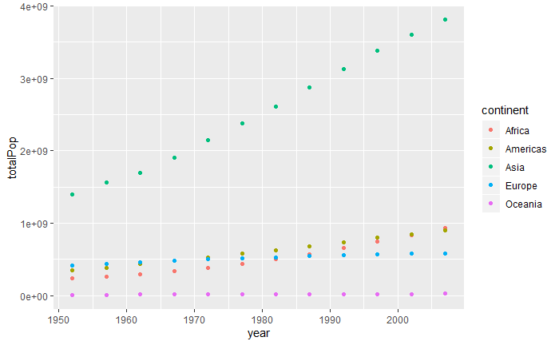

```r
# population over time by continent
ggplot(by_year_continent, aes(x = year, y = totalPop,
                              color = continent)) +
    geom_point() +
    expand_limits(y = 0)
```

Notice how we are not yet even using: meanLifeExp or medianGdpPerCap

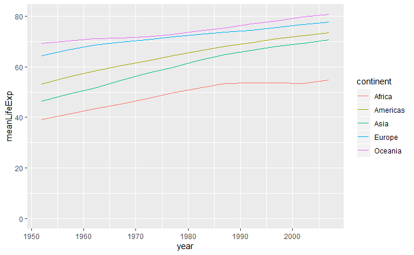

```r
# mean life expectancy over time by continent
ggplot(by_year_continent, aes(x = year, y = meanLifeExp,
                              color = continent)) +
    geom_line() +
    expand_limits(y = 0)
```

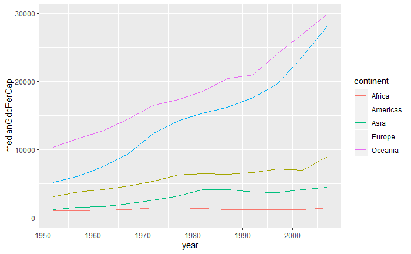

```r
# median GDP per capita over time by continent
ggplot(by_year_continent, aes(x = year, y = medianGdpPerCap,
                              color = continent)) +
    geom_line() +
    expand_limits(y = 0)
```

# bar plots

Two aesthetics in a bar plot. x = categorical variable. y = numeric. Bar plots always start at ZERO.

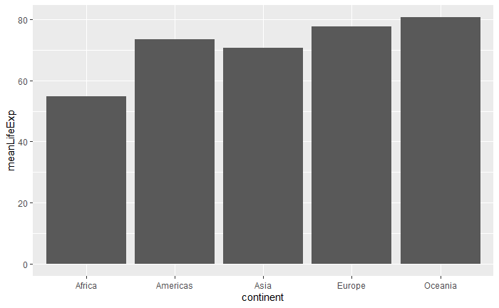

```r
# basic
# by_continent (above in group_by() section)
ggplot(by_continent, aes(x = continent, y = meanLifeExp)) +
    geom_col()
```

# histograms

Shows the distribution of a variable. Each bar is a “bin” and height is number of values in that bin. The number of bins is chosen automatically and has a large affect on how the histogram communicates the distribution. You can customize with the `binwidth = value` option.

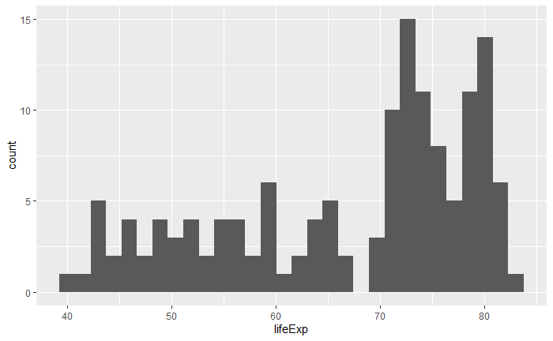

If we choose `binwidth = 5` it means each bar in the histogram represents a width of 5 years. Sometimes, you may also need the x-axis to be a log scale to be understandable.

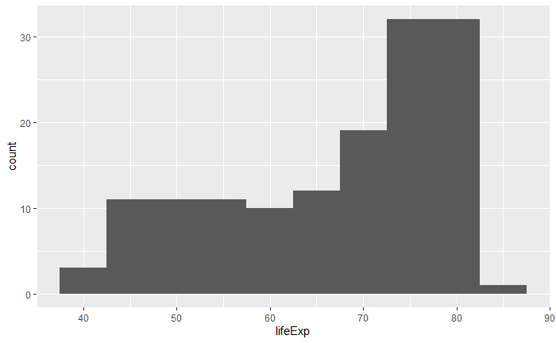

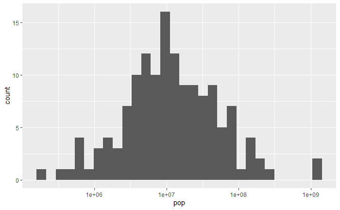

# box plots

Helps you understand the distribution of many variables (rather than 1 variable in a histogram). x is category. y is numeric value. Black line = median. Top and bottom of the box represent the 75th percentile and 25th percentile of the group. Meaning half of the distribution (middle 50%) lies within that box. The whiskers cover additional countries. The two dots for Asia and Americas represent outliers.

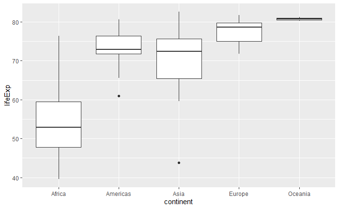

```r
# comparing distribution of life expectencies within each continent
ggplot(gapminder_2007, aes(x = continent, y = lifeExp)) +
    geom_boxplot()
```